# Titanic Analysis: What does it take to survive?

The story of the Titanic is one that has made its mark in history for the sheer loss of life. The following report analyzes a dataset provided by Kaggle that contains the records of 891 passengers from the doomed journey. The main question that this report tries to answer is if there are attributes that made a person more likely to survive. The three main factors that will be analyzed are: average fare price by gender, passenger class by gender, and whether the passenger was traveling alone by gender.

```python
#Read in packages and load dataset
import pandas as pd
import numpy as np
import matplotlib.pyplot as plt
import seaborn as sns
from __future__ import division
%pylab inline

titanic_df=pd.read_csv('titanic-data.csv')
```

```python
#Preview of data
print titanic_df.head()
```

```
   PassengerId  Survived  Pclass  \
0            1         0       3
1            2         1       1
2            3         1       3
3            4         1       1
4            5         0       3

                                                Name     Sex   Age  SibSp  \
0                            Braund, Mr. Owen Harris    male  22.0      1
1  Cumings, Mrs. John Bradley (Florence Briggs Th...  female  38.0      1
2                             Heikkinen, Miss. Laina  female  26.0      0
3       Futrelle, Mrs. Jacques Heath (Lily May Peel)  female  35.0      1
4                           Allen, Mr. William Henry    male  35.0      0

   Parch            Ticket     Fare Cabin Embarked
0      0         A/5 21171   7.2500   NaN        S
1      0          PC 17599  71.2833   C85        C
2      0  STON/O2. 3101282   7.9250   NaN        S
3      0            113803  53.1000  C123        S
4      0            373450   8.0500   NaN        S
```

## Data Set Investigation

```python
#Summary of data
titanic_df.info()
```

```
<class 'pandas.core.frame.DataFrame'>
RangeIndex: 891 entries, 0 to 890
Data columns (total 12 columns):
PassengerId    891 non-null int64
Survived       891 non-null int64
Pclass         891 non-null int64
Name           891 non-null object
Sex            891 non-null object
Age            714 non-null float64
SibSp          891 non-null int64
Parch          891 non-null int64
Ticket         891 non-null object
Fare           891 non-null float64
Cabin          204 non-null object
Embarked       889 non-null object
dtypes: float64(2), int64(5), object(5)
memory usage: 83.6+ KB
```

The figures above shows how many valid entries each column has in this dataset. It appears that 177 age records are missing along with the cabin number of 687 passengers. The aren't enough cabin records to determine if cabin location had an impact on survival. Pclass could be used as a proxy for this. The deck plans of the Titanic show what level each class was situated on. The higher the class, the higher the cabin location.

Given that dataset contains most of the records for age, this report will analyze this variable. A seperate dataset will be created with isolating entries that contain age data. Any other analysis will refer to the original passenger manifest dataset.

```python
#Count of entries by class for all entries in dataset
titanic_df.groupby('Pclass').agg(['count','mean'])
```

| Pclass | PassengerId count | PassengerId mean | Survived count | Survived mean | Age count | Age mean | SibSp count | SibSp mean | Parch count | Parch mean | Fare count | Fare mean |
| --- | --- | --- | --- | --- | --- | --- | --- | --- | --- | --- | --- | --- |
| 1 | 216 | 461.597222 | 216 | 0.629630 | 186 | 38.233441 | 216 | 0.416667 | 216 | 0.356481 | 216 | 84.154687 |
| 2 | 184 | 445.956522 | 184 | 0.472826 | 173 | 29.877630 | 184 | 0.402174 | 184 | 0.380435 | 184 | 20.662183 |
| 3 | 491 | 439.154786 | 491 | 0.242363 | 355 | 25.140620 | 491 | 0.615071 | 491 | 0.393075 | 491 | 13.675550 |

```python
#Count of entries by class for complete entries
titanic_df.dropna().groupby('Pclass').agg(['count','mean'])
```

| Pclass | PassengerId count | PassengerId mean | Survived count | Survived mean | Age count | Age mean | SibSp count | SibSp mean | Parch count | Parch mean | Fare count | Fare mean |
| --- | --- | --- | --- | --- | --- | --- | --- | --- | --- | --- | --- | --- |
| 1 | 158 | 467.221519 | 158 | 0.670886 | 158 | 37.591266 | 158 | 0.487342 | 158 | 0.468354 | 158 | 88.683228 |
| 2 | 15 | 343.266667 | 15 | 0.800000 | 15 | 25.266667 | 15 | 0.400000 | 15 | 0.400000 | 15 | 18.444447 |
| 3 | 10 | 436.200000 | 10 | 0.500000 | 10 | 21.000000 | 10 | 0.200000 | 10 | 0.700000 | 10 | 11.027500 |

```python
len(titanic_df.dropna())
```

```
183
```

Out of all the row in the dataset, only 183 contain data for every variable. The table above shows the number of entries per class. It appears that that most of the complete entries are for passengers in the first class. There are notable differences between the number of entries per class amongst the two datasets. No conclusive insights could be drawn from this. It is possible that was better record keeping for high class indviduals during this time. This a purely an assumption but is something to be investigated further.

```python
#Function converts survival outcome into text string
def survival_string(passenger):
    if passenger['Survived']==0:
        return "Did not Survive"
    else:
        return "Survived"
```

```python
#Add new column with survival outcome as text string
titanic_df['Survival']=titanic_df.apply(survival_string,axis=1)
```

```python
#Create family_size column
#The dataset provides two columns for group size SibSp(Sibling/Spouse) and Parch(Parent/child).
#These are combined to determine the size of the passengers group overall.
titanic_df['Family_Size']=titanic_df['SibSp']+titanic_df['Parch']
```

```python
#This function groups passengers by age group
def age_group(passenger):
    age=passenger['Age']
    if age <18:
        return 'child'
    elif age < 65:
        return 'adult'
    else:
        return 'senior'
```

```python
#Create age groups
titanic_df['AgeGroup']=titanic_df.apply(age_group,axis=1)
```

```python
#This function is used to determine if passenger was alone
def p_loner(passenger):
    group=passenger['Family_Size']
    if group >0:
        return 0
    else:
        return 1
```

```python
#Add column in data for alone/not alone
titanic_df['Alone']=titanic_df.apply(p_loner,axis=1)
```

```python
#Create new dataset for passengers with age data
titanic_aged_df = titanic_df[np.isfinite(titanic_df['Age'])]
```

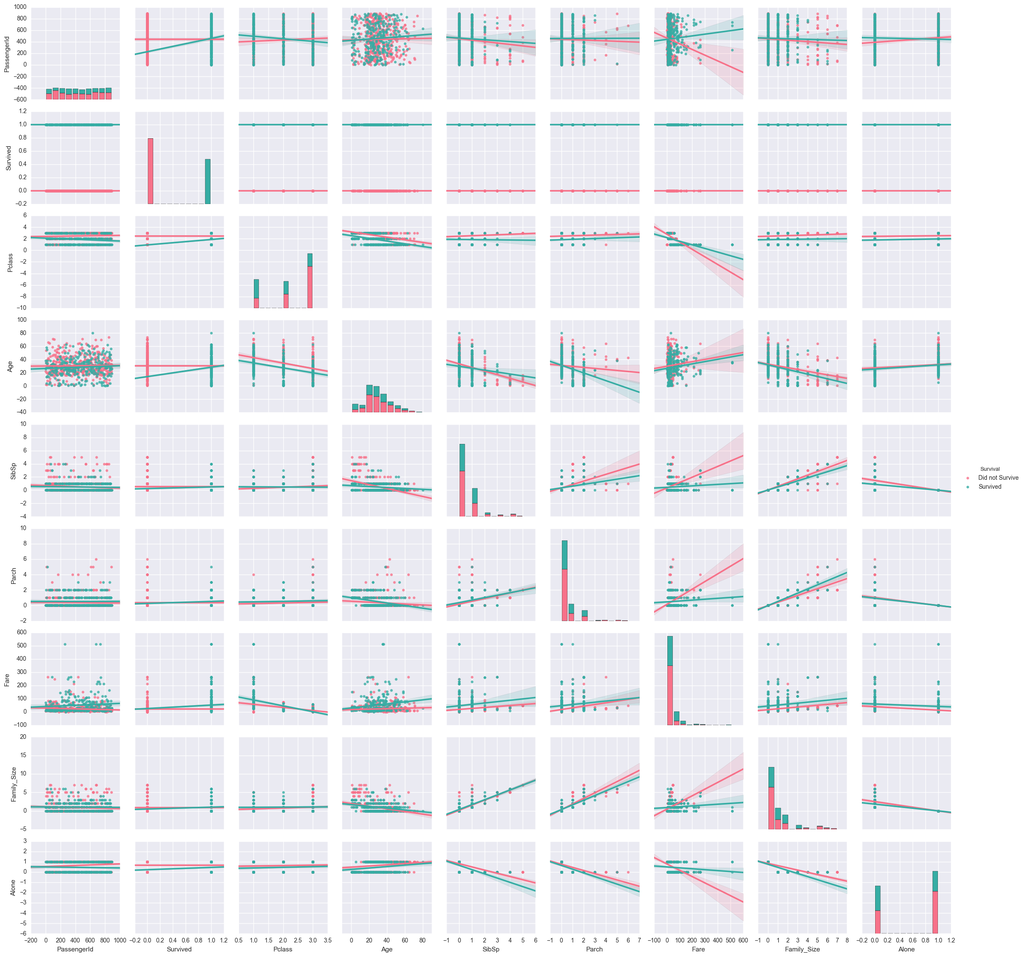

```python
#Overview of data
sns.pairplot(titanic_aged_df,hue='Survival',kind='reg',palette="husl")
```

The pairplot above gives an overview of the relationship between any two varibles in the dataset. At a glance, it seems like first and second passengers have a higher rate of survival than those in third. Higher classes pay more for their tickets, which one would expect. There were higher rates of survival for younger individuals and this is most notable for passengers in the third class. It seems like a majority of the passengers were between the ages of twenty and forty years old. It seems like there were lower rates of survival for indivduals who either did not come with a sibling/ spouse(Sibsp) or those without children/ parents(Parch). This will be explored in further detail. This report will look at indivudals who were either alone or not by grouping Sibsp and Parch variables.

## Demographics

```python
#Create df's for specific groups
male_aboard=titanic_df.loc[titanic_df['Sex']=='male']
female_aboard=titanic_df.loc[titanic_df['Sex']=='female']

first_class_aboard=titanic_df.loc[titanic_df['Pclass']==1]
second_class_aboard=titanic_df.loc[titanic_df['Pclass']==2]
third_class_aboard=titanic_df.loc[titanic_df['Pclass']==3]

alone_aboard=titanic_df.loc[titanic_df['Family_Size']==0]
not_alone_aboard=titanic_df.loc[titanic_df['Family_Size']==1]

child_aboard=titanic_aged_df.loc[titanic_aged_df['AgeGroup']=='child']
adult_aboard=titanic_aged_df.loc[titanic_aged_df['AgeGroup']=='adult']
senior_aboard=titanic_aged_df.loc[titanic_aged_df['AgeGroup']=='senior']
```

```python
#Demographics

print "Male on board:",len(male_aboard)
print "Female on board:",len(female_aboard)
print "Total passengers in sample", len(titanic_df)

print""
print "Total first class:",len(first_class_aboard)
print "Total second class:",len(second_class_aboard)
print "Total third class:",len(third_class_aboard)

print""
print "Total without family:",len(alone_aboard)
print "Total with family:",len(not_alone_aboard)


print""
print "Total children:",len(child_aboard)
print "Total adult:",len(adult_aboard)
print "Total senior:",len(senior_aboard)
```

[output not shown]

## Overiew of Survival Rates

```python
#Survival rates
print "Male survival rate:",float(len(male_aboard.loc[male_aboard['Survived']==1])/len(male_aboard))
print "Female survival rate:",float(len(female_aboard.loc[female_aboard['Survived']==1])/len(female_aboard))

print ""
print "First class survival rate:",float(len(first_class_aboard.loc[first_class_aboard['Survived']==1])/len(first_class_aboard))
print "Second class survival rate:",float(len(second_class_aboard.loc[second_class_aboard['Survived']==1])/len(second_class_aboard))
print "Third class survival rate:",float(len(third_class_aboard.loc[third_class_aboard['Survived']==1])/len(third_class_aboard))


print""
print "Without family survival rate:",float(len(alone_aboard.loc[alone_aboard['Survived']==1])/len(alone_aboard))
print "With family survival rate:",float(len(not_alone_aboard.loc[not_alone_aboard['Survived']==1])/len(not_alone_aboard))

print""
print "Child survival rate:",float(len(child_aboard.loc[child_aboard['Survived']==1])/len(child_aboard))
print "Adult survival rate:",float(len(adult_aboard.loc[adult_aboard['Survived']==1])/len(adult_aboard))
print "Senior survival rate:",float(len(senior_aboard.loc[senior_aboard['Survived']==1])/len(senior_aboard))
```

```
Male survival rate: 0.188908145581
Female survival rate: 0.742038216561

First class survival rate: 0.62962962963
Second class survival rate: 0.472826086957
Third class survival rate: 0.242362525458

Without family survival rate: 0.303538175047
With family survival rate: 0.552795031056

Child survival rate: 0.53982300885
Adult survival rate: 0.386440677966
Senior survival rate: 0.0909090909091
```

```python
#Filter by gender function to use with grouped df
def filter_male(row):
    return row.loc[row['Sex']=='male']
```

```python
#Filter by gender function to use with grouped df
def filter_female(row):
    return row.loc[row['Sex']=='female']
```

```python
#Filter by class function to use with grouped df
def filter_first(row):
    return row.loc[row['Pclass']==1]
```

```python
#Filter by class function to use with grouped df
def filter_second(row):
    return row.loc[row['Pclass']==2]
```

```python
#Filter by class function to use with grouped df
def filter_third(row):
    return row.loc[row['Pclass']==3]
```

```python
#Female survival by fare
female_passengers=titanic_aged_df.groupby(['Sex']).apply(filter_female)
female_survivor_fare=female_passengers.loc[female_passengers['Survived']==1]['Fare'].mean()
female_casualty_fare=female_passengers.loc[female_passengers['Survived']==0]['Fare'].mean()

print female_survivor_fare, female_casualty_fare

#print female_survived_fare.loc[female_survived_fare['Survived']==1]
```

```
55.6431477157 22.7718765625
```

```python
#Male survival by fare
male_passengers=titanic_aged_df.groupby(['Sex']).apply(filter_male)
male_survivor_fare=male_passengers.loc[male_passengers['Survived']==1]['Fare'].mean()
male_casualty_fare=male_passengers.loc[male_passengers['Survived']==0]['Fare'].mean()

print male_survivor_fare, male_casualty_fare
```

```
43.7938645161 22.9998705556
```

```python
#Group by class
first_class=titanic_aged_df.groupby(['Pclass']).apply(filter_first)
second_class=titanic_aged_df.groupby(['Pclass']).apply(filter_second)
third_class=titanic_aged_df.groupby(['Pclass']).apply(filter_third)
```

```python
#Female survival rate by class
female_first=first_class.loc[first_class['Sex']=='female']
female_first_survival=female_first['Survived'].mean()

female_second=second_class.loc[second_class['Sex']=='female']
female_second_survival=female_second['Survived'].mean()

female_third=third_class.loc[third_class['Sex']=='female']
female_third_survival=female_third['Survived'].mean()

print female_first_survival, female_second_survival, female_third_survival
```

```
0.964705882353 0.918918918919 0.460784313725
```

```python
#Male survival rate by class
male_first=first_class.loc[first_class['Sex']=='male']
male_first_survival=male_first['Survived'].mean()

male_second=second_class.loc[second_class['Sex']=='male']
male_second_survival=male_second['Survived'].mean()

male_third=third_class.loc[third_class['Sex']=='male']
male_third_survival=male_third['Survived'].mean()

print male_first_survival, male_second_survival, male_third_survival
```

```
0.39603960396 0.151515151515 0.150197628458
```

```python
#Alone vs. not alone survival rates by gender
female_by_groupsize=titanic_aged_df.groupby(['Alone']).apply(filter_female)
male_by_groupsize=titanic_aged_df.groupby(['Alone']).apply(filter_male)
```

## Female Survival: Accompanied vs. Alone

```python
#Female group size
female_alone=female_by_groupsize.loc[female_by_groupsize['Alone']==0]
female_alone_survival=female_alone['Survived'].mean()

female_accompanied=female_by_groupsize.loc[female_by_groupsize['Alone']==1]
female_accompanied_survival=female_accompanied['Survived'].mean()

male_alone=male_by_groupsize.loc[male_by_groupsize['Alone']==0]
male_alone_survival= male_alone['Survived'].mean()

male_accompanied=male_by_groupsize.loc[male_by_groupsize['Alone']==1]
male_accompanied_survival=male_accompanied['Survived'].mean()

print female_alone_survival, female_accompanied_survival, male_alone_survival, male_accompanied_survival
```

```
0.732919254658 0.79 0.281879194631 0.167763157895
```

[figure not shown]

[figure not shown]

```python
#Female Accompanied pie chart
labels = 'Survived', 'Casualty'
sizes = [(female_accompanied_survival*100), 100-(female_accompanied_survival*100)]

plt.figure(0)
fig1, ax1 = plt.subplots()
ax1.pie(sizes, labels=labels, autopct='%1.1f%%',
        shadow=True, startangle=90)
ax1.axis('equal')  # Equal aspect ratio ensures that pie is drawn as a circle.
title('Female Accompanied', bbox={'facecolor':'0.8', 'pad':5})

plt.figure(1)
labels = 'Survived', 'Casualty'
sizes = [female_alone_survival*100, (100-(female_alone_survival*100))]

fig1, ax1 = plt.subplots()
ax1.pie(sizes, labels=labels, autopct='%1.1f%%',
        shadow=True, startangle=90)
ax1.axis('equal')  # Equal aspect ratio ensures that pie is drawn as a circle.
title('Female Alone', bbox={'facecolor':'0.8', 'pad':5})


plt.show()
```

## Male Survival: Accompanied vs. Alone

[figure not shown]

[figure not shown]

```python
#Male Accompanied pie chart
import matplotlib.pyplot as plt
labels = 'Survived', 'Casualty'
sizes = [(male_accompanied_survival*100), 100-(male_accompanied_survival*100)]

plt.figure(0)
fig1, ax1 = plt.subplots()
ax1.pie(sizes, labels=labels, autopct='%1.1f%%',
        shadow=True, startangle=90)
ax1.axis('equal')  # Equal aspect ratio ensures that pie is drawn as a circle.
title('Male Accompanied', bbox={'facecolor':'0.8', 'pad':5})

plt.figure(1)
labels = 'Survived', 'Casualty'
sizes = [male_alone_survival*100, (100-(male_alone_survival*100))]

fig1, ax1 = plt.subplots()
ax1.pie(sizes, labels=labels, autopct='%1.1f%%',
        shadow=True, startangle=90)
ax1.axis('equal')  # Equal aspect ratio ensures that pie is drawn as a circle.
title('Male Alone', bbox={'facecolor':'0.8', 'pad':5})


plt.show()
```

## Female Survival by Class

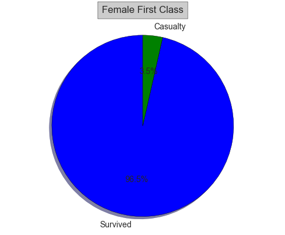

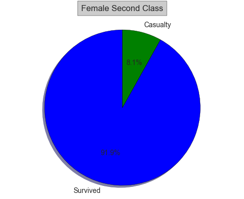

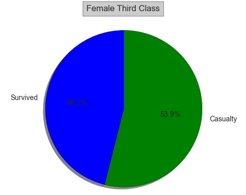

```python
#Female class survival pie charts
labels = 'Survived', 'Casualty'
sizes = [(female_first_survival*100), 100-(female_first_survival*100)]

plt.figure(0)
fig1, ax1 = plt.subplots()
ax1.pie(sizes, labels=labels, autopct='%1.1f%%',
        shadow=True, startangle=90)
ax1.axis('equal')  # Equal aspect ratio ensures that pie is drawn as a circle.
title('Female First Class', bbox={'facecolor':'0.8', 'pad':5},y=1.1)

plt.figure(1)

labels = 'Survived', 'Casualty'
sizes = [(female_second_survival*100), 100-(female_second_survival*100)]

fig1, ax1 = plt.subplots()
ax1.pie(sizes, labels=labels, autopct='%1.1f%%',
        shadow=True, startangle=90)
ax1.axis('equal')  # Equal aspect ratio ensures that pie is drawn as a circle.
title('Female Second Class', bbox={'facecolor':'0.8', 'pad':5},y=1.1)

plt.figure(2)

labels = 'Survived', 'Casualty'
sizes = [(female_third_survival*100), 100-(female_third_survival*100)]

fig1, ax1 = plt.subplots()
ax1.pie(sizes, labels=labels, autopct='%1.1f%%',
        shadow=True, startangle=90)
ax1.axis('equal')  # Equal aspect ratio ensures that pie is drawn as a circle.
title('Female Third Class', bbox={'facecolor':'0.8', 'pad':5},y=1.1)


plt.show()
```

The pie charts above shows that women in first and second class had a much greater chance of survival those in third.

## Male Survival by Class

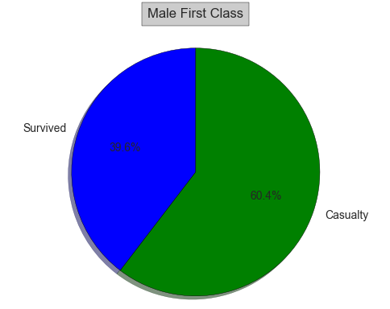

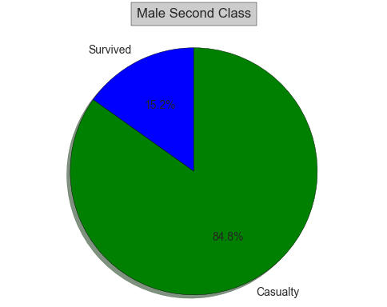

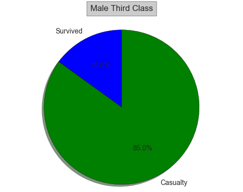

```python
#Male class survival pie charts
labels = 'Survived', 'Casualty'
sizes = [(male_first_survival*100), 100-(male_first_survival*100)]

plt.figure(0)
fig1, ax1 = plt.subplots()
ax1.pie(sizes, labels=labels, autopct='%1.1f%%',
        shadow=True, startangle=90)
ax1.axis('equal')  # Equal aspect ratio ensures that pie is drawn as a circle.
title('Male First Class', bbox={'facecolor':'0.8', 'pad':5},y=1.1)

plt.figure(1)

labels = 'Survived', 'Casualty'
sizes = [(male_second_survival*100), 100-(male_second_survival*100)]

fig1, ax1 = plt.subplots()
ax1.pie(sizes, labels=labels, autopct='%1.1f%%',
        shadow=True, startangle=90)
ax1.axis('equal')  # Equal aspect ratio ensures that pie is drawn as a circle.
title('Male Second Class', bbox={'facecolor':'0.8', 'pad':5},y=1.1)

plt.figure(2)

labels = 'Survived', 'Casualty'
sizes = [(male_third_survival*100), 100-(male_third_survival*100)]

fig1, ax1 = plt.subplots()
ax1.pie(sizes, labels=labels, autopct='%1.1f%%',
        shadow=True, startangle=90)
ax1.axis('equal')  # Equal aspect ratio ensures that pie is drawn as a circle.
title('Male Third Class', bbox={'facecolor':'0.8', 'pad':5},y=1.1)


plt.show()
```

The pie charts above show that male first class passengers had a greater higher chance of survival compared to other groups. One notable difference between these charts and those of women is that men in first class had a higher surival rate than both second and third. Another difference is that women had a higher chance of surival than men across all classes.

## Female Survival by Fare

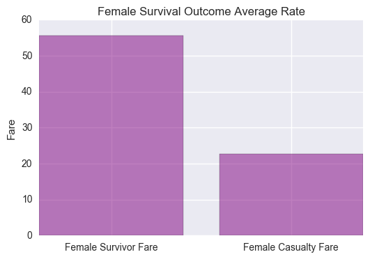

```python
objects = ('Female Survivor Fare', 'Female Casualty Fare')
y_pos = np.arange(len(objects))
outcome = [female_survivor_fare,female_casualty_fare]

plt.bar(y_pos, outcome, align='center', alpha=0.5,color="purple")
plt.xticks(y_pos, objects)
plt.ylabel('Fare')
plt.title('Female Survival Outcome Average Rate')
```

The bar chart above shows that women who survived paid more on average for their ticket than those who did not survive. This reflects the findings from the class survival by gender analysis.

## Male Survival by Fare

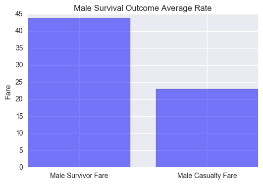

```python
objects = ('Male Survivor Fare', 'Male Casualty Fare')
y_pos = np.arange(len(objects))
outcome = [male_survivor_fare,male_casualty_fare]

plt.bar(y_pos, outcome, align='center', alpha=0.5,color="blue")
plt.xticks(y_pos, objects)
plt.ylabel('Fare')
plt.title('Male Survival Outcome Average Rate')
```

The bar chart above shows that male survivors paid a higher fare on average than those who did not survive. As in the findings for the womens survival by fare, this chart reflects the finds from the passenger class by gender analysis. There is less of a difference between fares of men who survived versus casualities which is highlights the notably higher survival rate for male first class passengers as opposed to others.

## Additional Insights

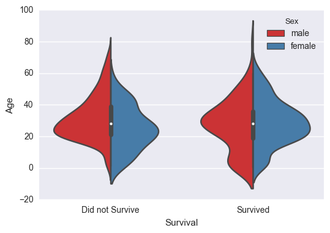

```python
#showing the ages of survivors vs the ages of those who perished
ax=sns.violinplot(x='Survival',y='Age',hue='Sex',palette='Set1', split=True,data=titanic_aged_df)
```

The violin plot above shows the the frequency of survival outcome by age and sex. One could infer that there was a higher rate of survival for passengers younger than 20 years old. There may have been a preference to load children onto lifeboats before others.

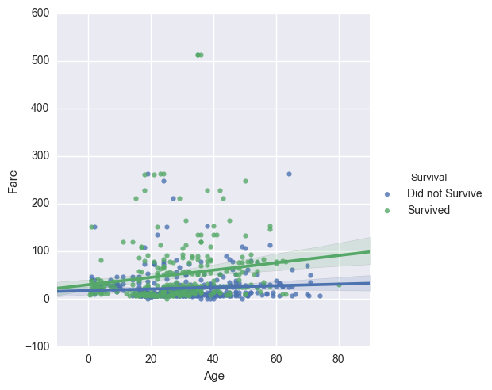

```python
sns.lmplot(x='Age', y='Fare',hue= 'Survival',data=titanic_aged_df,fit_reg=True)
```

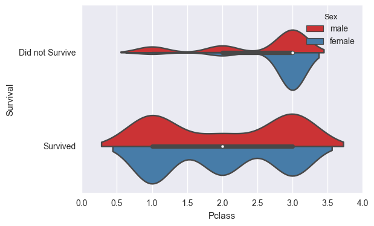

```python
ax=sns.violinplot(x='Pclass',y='Survival',hue='Sex',palette='Set1', split=True,data=titanic_df)
```

The violin chart above reiterates the previous findings that there was a higher rate of survival for passengers in the first and second class. This may have been due to the location of the life boats as opposed to different treatment by social class. Given that the cabins of first and second class passengers were closer to the main deck, it likely played a role in the outcome of their survival.

## Conclusion

Women had higher rates of survival overall compared to men. These findings are in line with the historical accounts of the wreck which state that women and children were a priority.

Passengers traveling in first class had a higher rate of survival across both genders. This does not necessarily mean that there could have been a preferance for higher class individuals. One thing to note about the Titanic is that lower classes were located on lower decks. Given that the glacial impact occured at 11PM, one could argue that many passengers were in their respective quarters. First and second class passengers were closer to the main deck which may have given them an upper hand.

While the findings in this report are suggestive, all conclusions are tentative and the aforementioned correlations are not meant to imply causality. With that said, the data from this voyage contains trends that continues to attract the attention of countless data analytic aficionados.